# An Ensemble Model to Predict the Bike Sharing Demand in Seoul: Development and Evaluation

I Brooks

April 2025

**Aim of Project**

In this project, I aim to predict the bike sharing demand in Seoul, South Korea, based on predictive weather condition and date variables. I will create a heterogeneous learner from bagged linear regression models, decision trees, and support vector machines.

**Data Reference**

Seoul Bike Sharing Demand [Dataset]. (2020). UCI Machine Learning Repository. https://doi.org/10.24432/C5F62R.

## Data exploration and wrangling

**Loading data**

```r
url <- "https://drive.google.com/uc?id=11-EkwrPO-ZL_ED6B4urADuC26zrupwNk&export=download"

df <- read.csv(url, fileEncoding = "Latin1",
               header = T, stringsAsFactors = T)
```

**Initial look at data**

```r
head(df)
```

```
##         Date Rented.Bike.Count Hour Temperature..C. Humidity...
## 1 01/12/2017               254    0            -5.2          37
## 2 01/12/2017               204    1            -5.5          38
## 3 01/12/2017               173    2            -6.0          39
## 4 01/12/2017               107    3            -6.2          40
## 5 01/12/2017                78    4            -6.0          36
## 6 01/12/2017               100    5            -6.4          37
##   Wind.speed..m.s. Visibility..10m. Dew.point.temperature..C.
## 1              2.2             2000                     -17.6
## 2              0.8             2000                     -17.6
## 3              1.0             2000                     -17.7
## 4              0.9             2000                     -17.6
## 5              2.3             2000                     -18.6
## 6              1.5             2000                     -18.7
##   Solar.Radiation..MJ.m2. Rainfall.mm. Snowfall..cm. Seasons    Holiday
## 1                       0            0             0  Winter No Holiday
## 2                       0            0             0  Winter No Holiday
## 3                       0            0             0  Winter No Holiday
## 4                       0            0             0  Winter No Holiday
## 5                       0            0             0  Winter No Holiday
## 6                       0            0             0  Winter No Holiday
##   Functioning.Day
## 1             Yes
## 2             Yes
## 3             Yes
## 4             Yes
## 5             Yes
## 6             Yes
```

*Conclusions*: There are 8760 observations, and 14 features in this data, including the target variable. The feature names have more characters than is necessary for the information to come across, I will rename them. There are 10 numeric features, 3 categorical features, and 1 date feature.

I will rename the columns to that they are easier to read. New column names:

```
##  [1] "Date"              "Rented.Bike.Count" "Hour"
##  [4] "Temperature"       "Humidity"          "Wind.Speed"
##  [7] "Visibility"        "Dew.Point"         "Solar.Radiation"
## [10] "Rainfall"          "Snowfall"          "Season"
## [13] "Holiday"           "Functioning.Day"
```

I will change date into a date object, so that I can use it for feature engineering in the future.

```r
# making date object in year-month-day form
df$Date <- as.Date(df$Date, "%d/%m/%Y")
```

### Encoding categorical features

I will perform one-hot encoding for the categorical features, Holiday, Functioning.Day, and Season.

```r
df$Holiday <- ifelse((df$Holiday == "Holiday"), 1, 0)
df$Functioning.Day <- ifelse((df$Functioning.Day == "Yes"), 1, 0)

df <- dummy_cols(df, select_columns = c("Season"))

# removing old season feature
df <- subset(df, select = -c(Season))
```

Holiday and Functioning.Day are binary features, which makes one-hot encoding ideal for them. Season only has 4 levels, which also makes on-hot encoding an appropriate choice for it.

### Feature engineering

**Features I will engineer**

- muggy: binary that is True when the temperature is above 24 degrees C, and humidity is over 65%
- month: includes information about the month of year
- weekend: binary feature that is True on Saturdays and Sundays
- morning: binary feature that is True when the hour is noon or earlier
- is_rain: binary feature that is true when Rainfall is greater than 0
- is_snow: binary feature that is true when Snowfall is greater than 0
- is_radiation: binary feature that is true when Solar.Radiation is greater than 0

Looking at the data with new, engineered features

```r
head(df, 5)
```

```
##   Rented.Bike.Count Hour Temperature Humidity Wind.Speed Visibility Dew.Point
## 1               254    0        -5.2       37        2.2       2000     -17.6
## 2               204    1        -5.5       38        0.8       2000     -17.6
## 3               173    2        -6.0       39        1.0       2000     -17.7
## 4               107    3        -6.2       40        0.9       2000     -17.6
## 5                78    4        -6.0       36        2.3       2000     -18.6
##   Solar.Radiation Rainfall Snowfall Holiday Functioning.Day Season_Autumn
## 1               0        0        0       0               1             0
## 2               0        0        0       0               1             0
## 3               0        0        0       0               1             0
## 4               0        0        0       0               1             0
## 5               0        0        0       0               1             0
##   Season_Spring Season_Summer Season_Winter muggy month weekend morning is_rain
## 1             0             0             1     0    12       0       1       0
## 2             0             0             1     0    12       0       1       0
## 3             0             0             1     0    12       0       1       0
## 4             0             0             1     0    12       0       1       0
## 5             0             0             1     0    12       0       1       0
##   is_snow is_radiation
## 1       0            0
## 2       0            0
## 3       0            0
## 4       0            0
## 5       0            0
```

### Categorizing features

**Numeric features**: Temperature, Humidity, Wind.Speed, Visibility, Dew.Point, Solar.Radiation, Rainfall, Snowfall

**Categorical features**: Hour, Holiday, Functioning.Day, muggy, month, weekend, Season_Summer, Season_Autumn, Season_Winter, Season_Spring, is_rain, is_snow, is_radiation

**Target feature**: Rented.Bike.Count

### Visualizing data

Visualizing distributions of numeric features

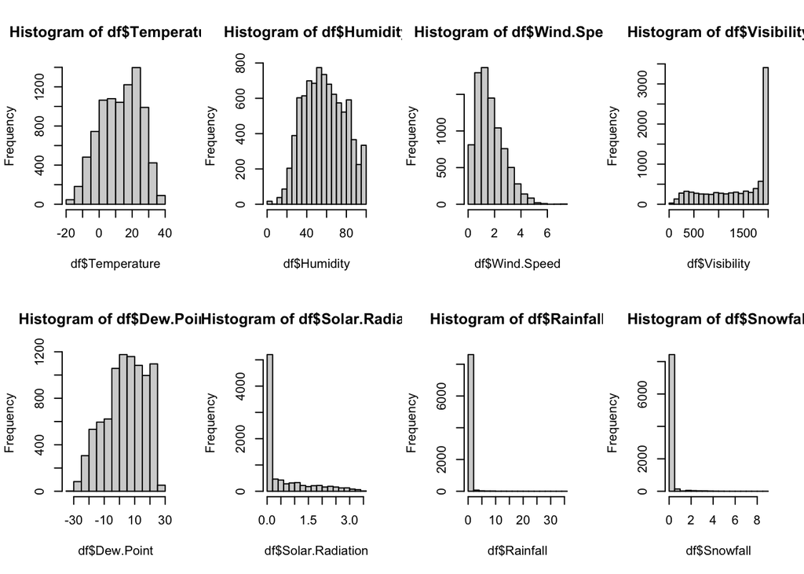

- Wind.Speed, Solar. Radiation, Rainfall, and Snowfall all appear to be right skewed, I will handle outliers
- Visibility appears to be left-skewed, I will handle outliers.
- Temperature, Humidity, and Dew.Point appear reasonably normally distributed.

**Seeing the relationship between month and rented bike count**

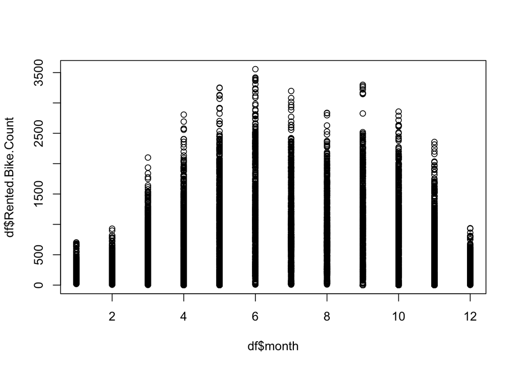

*Conclusions*: The relationship between date and rented bike count appears to be bimodal. There are peaks in June and September. The rented bike count drastically decreases in winter months.

**Seeing the relationship between Hour and Rented.Bike.Count**

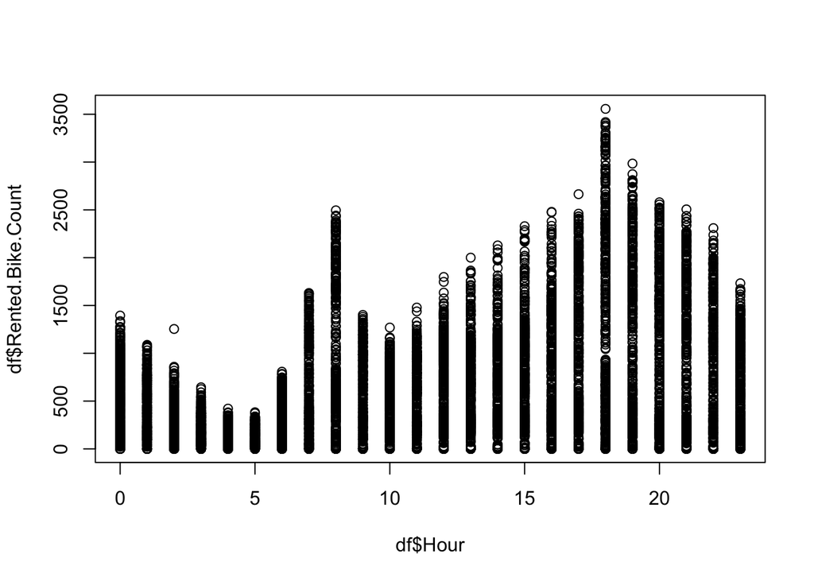

*Conclusions*: It appears that the relationship between Hour and Rented.Bike.Count is bimodal. There is a peak in the morning around 8 am, and another peak in the evening around 6 pm.

### Missing values

This function counts the number of missing values in a dataset, and reports them.

```r
count_missing <- function (x) {
  presence_na <- 0

  # iterate through each row
  for (i in colnames(df)) {
    # find rows with NA values
    na_rows <- which(is.na(df[i]))
    # find num NA's
    num_na <- length(na_rows)
    # report findings
    if (num_na > 0) {
      print(paste0(i, " has ", num_na, " NA values in rows: "))
      print(na_rows)
      presence_na <- presence_na + 1
    }
  } # end of for

  if (presence_na == 0) {
    print("There are no missing values in the dataset.")
  }

} # end of function

count_missing(0)
```

```
## [1] "There are no missing values in the dataset."
```

Since there are no missing values in this dataset, I will randomly remove some values from Wind.Speed so that I can demonstrate how I would impute them.

First, I will randomly removing some NA values from Wind.Speed

```r
set.seed(101010)
# randomly generating 10 row numbers from df
random_rows <- sample(nrow(df), 10, replace = F)

# making 10 rows NA
for (i in random_rows) {
  df$Wind.Speed[i] <- NA
}

# checking it worked
count_missing(0)
```

```
## [1] "Wind.Speed has 10 NA values in rows: "
##  [1] 3793 5079 6079 6433 6646 6896 8076 8349 8391 8735
```

There is not a strong correlation between Wind.Speed and ant other features, so I will not use other features to help guide imputation.

The distribution of Wind.Speed showed earlier demonstrated how it has a slightly right-skewed distribution. In order to minimize the influence skew may have on my handling of missing values, I will use median-imputation.

```r
med_wind_speed <- median(df$Wind.Speed, na.rm = T)

for (i in 1:nrow(df)) {
  # replacing missing values with median value
  if(is.na(df$Wind.Speed[i])) {
    df$Wind.Speed[i] <- med_wind_speed
  }
}

# checking it worked
count_missing(0)
```

```
## [1] "There are no missing values in the dataset."
```

Making sure the distribution wasn’t heavily affected

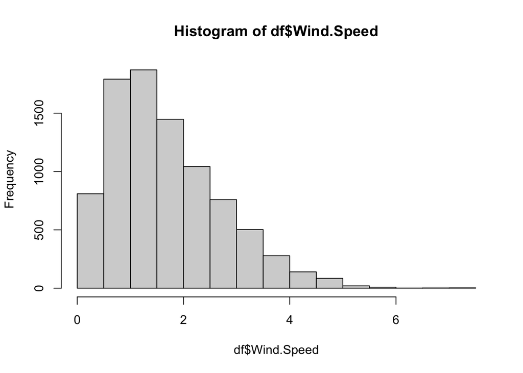

```r
hist(df$Wind.Speed)
```

The Wind.Speed distribution seems largely unchanged, I am satisfied with the quality of my imputation.

### Outliers

**Finding which columns have outliers**

```r
# keeping track of columns with outliers
outlier_cols <- c()

# going through numeric features only
for (i in colnames(num_df)) {
  # z-score outlier identification
  outliers <- which(abs(scale(num_df[i])) >= 3)

  # message if outliers found
  if (length(outliers) > 0) {
    print(paste0(i, " has ", length(outliers), " outliers"))
    outlier_cols[i] <- i
  }
}
```

```
## [1] "Wind.Speed has 63 outliers"
## [1] "Solar.Radiation has 85 outliers"
## [1] "Rainfall has 94 outliers"
## [1] "Snowfall has 173 outliers"
```

*Conclusions*: There are quite a lot of outliers in 4 numeric features. I will use median-imputation for the outliers, in order to minimize the impact their skews may have on imputation.

**Median-imputing outliers**

```r
# looping through columns that were found to have outliers
for (i in outlier_cols) {
  # getting median value for the column
  median_val <- median(df[[i]])

  # identifying rows with outliers
  outliers <- which(abs(scale(num_df[i])) >= 3)

  for (j in outliers) {
    df[j, i] <- median_val
  }
}
```

**Seeing distributions after outliers are handled**

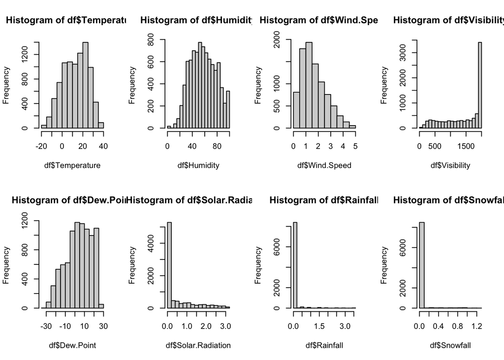

```r
distributions(0)
```

*Conclusions*: Wind.Speed, Solar.Radiation, Rainfall, and Snowfall still appear quite heavily right-skewed after removing outliers, so I will perform transformations to make them more reasonably normal. Same with Visibility, but it is heavily left-skewed instead.

### Transforming data

I will perform a Yeo-Johnson transformation on my heavily skewed data in an attempt to normalize it.

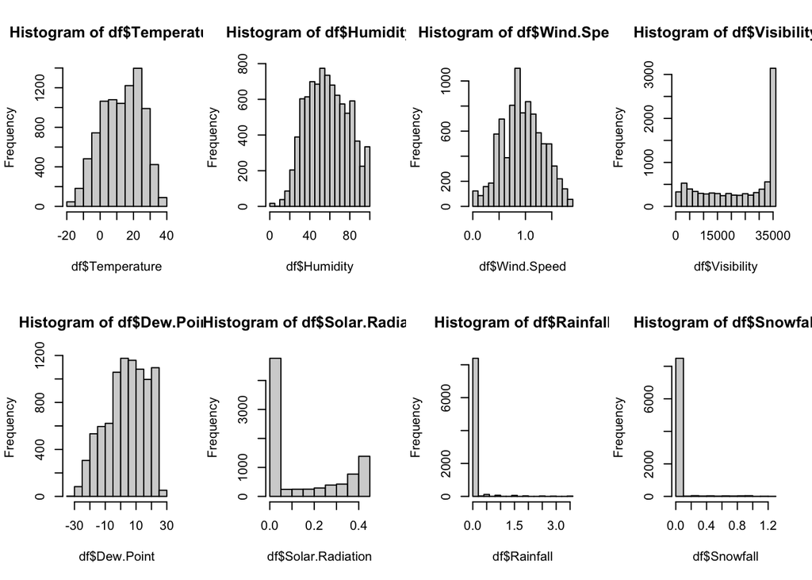

```r
transorm_intermed <- preProcess(df[c("Solar.Radiation", "Rainfall", "Visibility", "Snowfall", "Wind.Speed")], method = c("YeoJohnson"))

df <- predict(transorm_intermed, df)

distributions(0)
```

*Conclusions*: There are still heavy skews in Solar.Radiation, Rainfall, Snowfall, and Visibility. I will examine their correlation with the target variable, and decide what next steps to take

### Decision Tree Data

I will use the data that has been pre-processed to this point for decision tree models. Decision trees are robust to different data distributions, so standardization is not necessary.

```r
tree_df <- df
```

### Standardization

I will continue to standardize data for use in SVM and linear regression models, which use distance measurements in their algorithms, and are sensitive to large differences in data ranges.

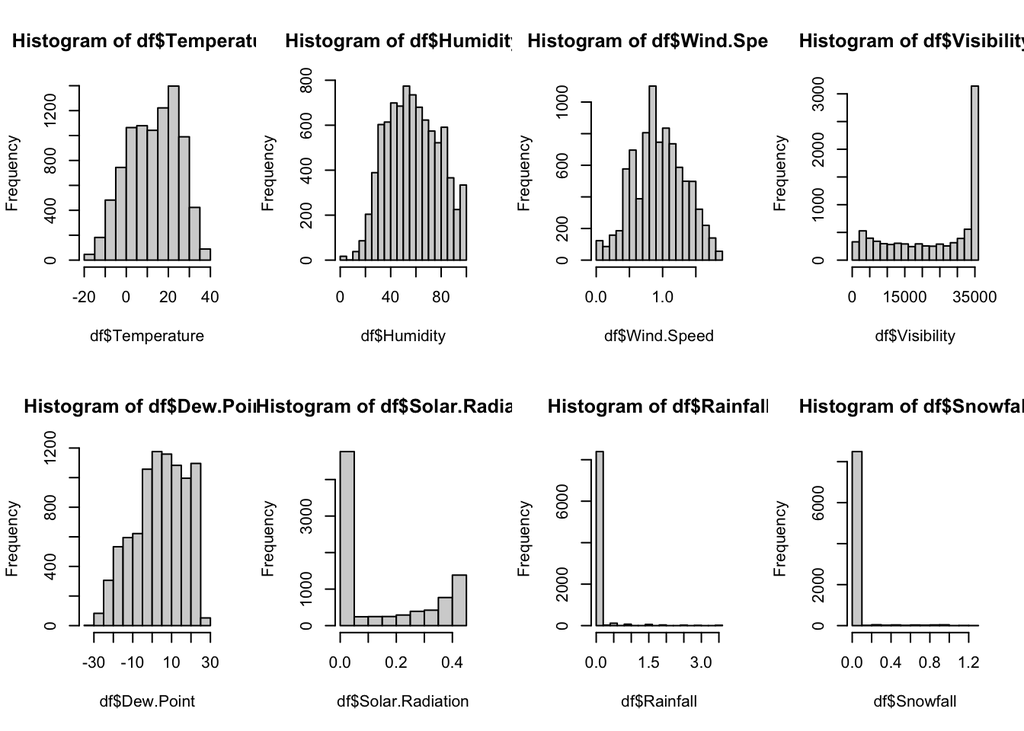

```r
numeric_features <- c("Temperature", "Humidity", "Wind.Speed", "Visibility", "Dew.Point", "Solar.Radiation", "Rainfall", "Snowfall")

num_df <- df[numeric_features]
cat_df <- df[, -which(names(df) %in% numeric_features)]

# applying z-score standardization to numeric features
z_df <- data.frame(cat_df, apply(num_df, 2, scale))

# checking it worked
distributions(0)
```

*Conclusions*: Standardizing has not improved the skew of Solar.Radiation, Rainfall, Snowfall, and Visibility. These skews will have to be considered when performing feature selection

### Principal Component Analysis

Performing PCA on standardized numeric features

```r
pca_data <- princomp(z_df[numeric_features])
summary(pca_data)
```

```
## Importance of components:
##                           Comp.1    Comp.2    Comp.3    Comp.4     Comp.5
## Standard deviation     1.5669753 1.3738625 1.0434707 0.9401653 0.88634697
## Proportion of Variance 0.3069615 0.2359642 0.1361194 0.1105015 0.09821258
## Cumulative Proportion  0.3069615 0.5429257 0.6790451 0.7895466 0.88775916
##                            Comp.6     Comp.7       Comp.8
## Standard deviation     0.79552515 0.51010898 0.0689405409
## Proportion of Variance 0.07911656 0.03253011 0.0005941676
## Cumulative Proportion  0.96687572 0.99940583 1.0000000000
```

Looking at breakdowns of the first four principal components

```r
pca_data$loadings[, 1:4]
```

```
##                     Comp.1     Comp.2        Comp.3       Comp.4
## Temperature      0.4011289  0.5297629  0.0212386413  0.155498530
## Humidity         0.5154221 -0.2945692 -0.0928698838  0.110874712
## Wind.Speed      -0.2693757  0.2926366 -0.5236747326 -0.060468030
## Visibility      -0.3187839  0.2896904  0.3581400801 -0.063568930
## Dew.Point        0.5489371  0.3306449  0.0005087084  0.187979898
## Solar.Radiation -0.1475023  0.5242850 -0.3348755459 -0.001408583
## Rainfall         0.2277763 -0.1390471 -0.4934609343 -0.668166618
## Snowfall        -0.1558150 -0.2439029 -0.4824717386  0.688508938
```

*Conclusions*:

## Modeling

### Splitting data

I will split the data prepared for the linear regression, decision tree, and SVM algorithms, so that I can evaluate the models using the holdout method.

```r
seeds <- c(101010, 1234, 5678)

lr_svm_train <- list()
lr_svm_test <- list()
tree_train <- list()
tree_test <- list()

for (i in 1:length(seeds)) {
  # setting a unique seed for each split
  set.seed(seeds[i])
  # randomly splitting 80-20 for lr and svm
  lr_svm_train_index <- createDataPartition(z_df$Rented.Bike.Count, p = 0.8, list = F, times = 1)

  # splitting for tree
  set.seed(seeds[i])
  # randomly splitting 80-20 for tree
  tree_train_index <- createDataPartition(tree_df$Rented.Bike.Count, p = 0.8, list = F, times = 1)

  # adding to list of data frames
  lr_svm_train[[i]] <- z_df[lr_svm_train_index,]
  lr_svm_test[[i]] <- z_df[-lr_svm_train_index,]
  tree_train[[i]] <- tree_df[tree_train_index,]
  tree_test[[i]] <- tree_df[-tree_train_index,]
}

# checking it worked
length(lr_svm_train)
```

```
## [1] 3
```

```r
nrow(lr_svm_train[[1]])
```

```
## [1] 7009
```

### Evaluation function

I will build a generalized evaluation function that will return RMSE and R2 statistics in order to evaluate model fit and accuracy.

```r
model_stats <- function(model, data) {
  # get predictions
  predictions <- predict(model, data)

  # calculate RMSE
  sq_err <- (data["Rented.Bike.Count"] - predictions)^2
  MSE <- mean(sq_err[["Rented.Bike.Count"]])
  RMSE <- sqrt(MSE)

  # calculate R2
  RSS <- sum(sq_err)
  TSS <- sum((data["Rented.Bike.Count"] - mean(data[["Rented.Bike.Count"]]))^2)
  R2 <- 1 - (RSS / TSS)

  # printing message
  print(paste0("The RMSE is: ", round(RMSE, 3)))
  print(paste0("The R2 is: ", round(R2, 3)))

  return(list(RMSE, R2))
}
```

### Homogeneous ensemble function

I will create a generalized homogeneous ensemble method to use bagging to get consensus predictions from the models created from different splits of the data

```r
homogeneous_ensemble <- function(first_model, second_model, third_model, new_data) {
  final_predictions <- c()

  # going through each row in the data
  for (i in 1:nrow(new_data)) {

    # making predictions with each model
    model1_prediction <- predict(first_model, new_data[i,])
    model2_prediction <- predict(second_model, new_data[i,])
    model3_prediction <- predict(third_model, new_data[i,])

    # averaging predictions
    average_prediction <- (model1_prediction + model2_prediction +
                             model3_prediction) / 3

    # adding to vector of final prediction values
    final_predictions[i] <- average_prediction
  }

  return(final_predictions)
}
```

### Linear Regression

#### Linear Regression k-fold cross validation

I will use cross validation for the linear regression model in order to evaluate fit.

```r
set.seed(101010)
control <- trainControl(method = "cv", number = 5)

lr_cv_model <- train(Rented.Bike.Count ~ Temperature +
                 Hour +
                 morning +
                 is_radiation +
                 Functioning.Day +
                 is_rain +
                 Season_Summer,
               method = "lm",
               data = z_df,
               trControl = control)

print(lr_cv_model)
```

```
## Linear Regression
##
## 8760 samples
##    7 predictor
##
## No pre-processing
## Resampling: Cross-Validated (5 fold)
## Summary of sample sizes: 7007, 7009, 7008, 7008, 7008
## Resampling results:
##
##   RMSE      Rsquared   MAE
##   437.0212  0.5411447  329.4325
##
## Tuning parameter 'intercept' was held constant at a value of TRUE
```

*Conclusions*:

- There are no hyperparameters to tune for linear regression models
- The RMSE for this model is 437.021, which is fairly high
- The R squared for this model is 0.541 which is not indicative of a very good fit for the model.
- Perhaps linear regression is not the most optimal modelling algorithm to use for this project.

#### Model 1

```r
lm_model_1 <- lm(Rented.Bike.Count ~ Temperature + Hour + morning + is_radiation + Functioning.Day + is_rain + Season_Summer,
                 data = lr_svm_train[[1]])

stats_model_1 <- model_stats(lm_model_1, lr_svm_test[[1]])
```

```
## [1] "The RMSE is: 445.819"
## [1] "The R2 is: 0.529"
```

*Conclusions*: Neither the R2 nor the RMSE are very good for this model. The statistics generated in k-fold cross validation are better.

#### Model 2

```r
lm_model_2 <- lm(Rented.Bike.Count ~ Temperature + Hour + morning + is_radiation + Functioning.Day + is_rain + Season_Summer, data = lr_svm_train[[2]])

stats_model_2 <- model_stats(lm_model_2, lr_svm_test[[2]])
```

```
## [1] "The RMSE is: 452.85"
## [1] "The R2 is: 0.528"
```

#### Model 3

```r
lm_model_3 <- lm(Rented.Bike.Count ~ Temperature + Hour + morning + is_radiation + Functioning.Day + is_rain + Season_Summer, data = lr_svm_train[[3]])

stats_model_3 <- model_stats(lm_model_3, lr_svm_test[[3]])
```

```
## [1] "The RMSE is: 439.604"
## [1] "The R2 is: 0.514"
```

#### Linear Regression Ensemble

```r
# making ensemble predictions
lr_ensemble_predictions <- homogeneous_ensemble(lm_model_1,
                                                lm_model_2,
                                                lm_model_3,
                                                z_df)

# evaluating homogeneous ensemble
lr_ensemble_stats <- sqrt(mean((z_df$Rented.Bike.Count - lr_ensemble_predictions)^2))

RSS <- sum((z_df$Rented.Bike.Count - lr_ensemble_predictions)^2)
TSS <- sum((z_df$Rented.Bike.Count - mean(z_df$Rented.Bike.Count))^2)
lr_ensemble_R2 <- 1 - (RSS / TSS)


print(paste0("The RMSE is: ", round(lr_ensemble_stats, 3)))
```

```
## [1] "The RMSE is: 436.871"
```

```r
print(paste0("The R2 is: ", round(lr_ensemble_R2, 3)))
```

```
## [1] "The R2 is: 0.541"
```

*Conclusions*: The homogeneous ensemble for the linear regression models has the best RMSE and R2 yet. Bagging improved the performance of linear regression.

### Decision Tree

#### Decision Tree k-fold cross validation

I will use cross validation for the decision tree model in order to evaluate fit, and to determine which decision tree algorithm is the most appropriate for this data.

```r
set.seed(101010)
control <- trainControl(method = "cv", number = 5)

tree_cv <- train(Rented.Bike.Count ~ Temperature +
                 Hour +
                 morning +
                 is_radiation +
                 Functioning.Day +
                 is_rain +
                 Season_Summer,
               method = "ctree",
               data = tree_df,
               trControl = control)

print(tree_cv)
```

```
## Conditional Inference Tree
##
## 8760 samples
##    7 predictor
##
## No pre-processing
## Resampling: Cross-Validated (5 fold)
## Summary of sample sizes: 7007, 7009, 7008, 7008, 7008
## Resampling results across tuning parameters:
##
##   mincriterion  RMSE      Rsquared   MAE
##   0.01          298.0947  0.7865509  188.6604
##   0.50          305.0577  0.7764174  194.7984
##   0.99          314.4031  0.7625914  203.6840
##
## RMSE was used to select the optimal model using the smallest value.
## The final value used for the model was mincriterion = 0.01.
```

*Conclusions*: I used a few different methods to determine which decision tree algorithm would also be the most appropriate for this data. Settled on the conditional inference tree algorithm, which performed the best. This model is well-suited to the data, as the target variable is continuous.

#### Model 1

Building first decision tree model with optimized hyperparameters

```r
tree_model_1 <- ctree(Rented.Bike.Count ~ Temperature +
                        Hour + morning +
                        is_radiation +
                        Functioning.Day +
                        is_rain +
                        Season_Summer,
                      data = tree_train[[1]],
                      control = ctree_control(mincriterion = 0.01))

# evaluating with holdout method
stats_tree_model_1 <- model_stats(tree_model_1, tree_test[[1]])
```

```
## [1] "The RMSE is: 299.635"
## [1] "The R2 is: 0.787"
```

*Conclusions*: The RMSE and R2 have greatly improved for this model, compared to the linear regression models. This model is more suitable for this project.

#### Model 2

Building second decision tree model for bagging with optimized hyperparameters

```r
tree_model_2 <- ctree(Rented.Bike.Count ~ Temperature +
                        Hour + morning +
                        is_radiation +
                        Functioning.Day +
                        is_rain +
                        Season_Summer,
                      data = tree_train[[2]],
                      control = ctree_control(mincriterion = 0.01))

# evaluating with holdout method
stats_tree_model_2 <- model_stats(tree_model_2, tree_test[[2]])
```

```
## [1] "The RMSE is: 291.645"
## [1] "The R2 is: 0.804"
```

*Conclusions*: The RMSE and R2 have slightly improved for this model. This split of data has created a marginally better model.

#### Model 3

Building third decision tree model for bagging with optimized hyperparameters

```r
tree_model_3 <- ctree(Rented.Bike.Count ~ Temperature +
                        Hour + morning +
                        is_radiation +
                        Functioning.Day +
                        is_rain +
                        Season_Summer,
                      data = tree_train[[3]],
                      control = ctree_control(mincriterion = 0.01))

# evaluating with holdout method
stats_tree_model_3 <- model_stats(tree_model_3, tree_test[[3]])
```

```
## [1] "The RMSE is: 312.126"
## [1] "The R2 is: 0.755"
```

#### Decision Tree Ensemble

```r
# making homogeneous predictions
tree_ensemble_predictions <- homogeneous_ensemble(tree_model_1,
                                                  tree_model_2,
                                                  tree_model_3,
                                                  tree_df)

# evaluating bagged model
tree_ensemble_stats <- sqrt(mean((tree_df$Rented.Bike.Count - tree_ensemble_predictions)^2))

RSS <- sum((tree_df$Rented.Bike.Count - tree_ensemble_predictions)^2)
TSS <- sum((tree_df$Rented.Bike.Count - mean(tree_df$Rented.Bike.Count))^2)
tree_ensemble_R2 <- 1 - (RSS / TSS)


print(paste0("The RMSE is: ", round(tree_ensemble_stats, 3)))
```

```
## [1] "The RMSE is: 267.834"
```

```r
print(paste0("The R2 is: ", round(tree_ensemble_R2, 3)))
```

```
## [1] "The R2 is: 0.828"
```

*Conclusions*: The RMSE and R2 are the best they have ever been for this homogeneous learner. Bagging improved this model. The R2 indicates that this model is an appropriate choice for this project. This model is better than the linear regression model for this project

### SVM

#### SVM k-fold cross validation

I will use cross validation for the SVM models in order to evaluate fit, and to determine which SVM kernel is the most appropriate for this data.

```r
set.seed(101010)
control <- trainControl(method = "cv", number = 5)

svm_cv <- train(Rented.Bike.Count ~ Temperature +
                        Hour + morning +
                        is_radiation +
                        Functioning.Day +
                        is_rain +
                        Season_Summer,
                       method = "svmRadial",
                       data = z_df,
                       trControl = control)

print(svm_cv)
```

```
## Support Vector Machines with Radial Basis Function Kernel
##
## 8760 samples
##    7 predictor
##
## No pre-processing
## Resampling: Cross-Validated (5 fold)
## Summary of sample sizes: 7007, 7009, 7008, 7008, 7008
## Resampling results across tuning parameters:
##
##   C     RMSE      Rsquared   MAE
##   0.25  310.8927  0.7694946  193.3514
##   0.50  308.7418  0.7721447  190.5061
##   1.00  307.2021  0.7741325  188.5957
##
## Tuning parameter 'sigma' was held constant at a value of 0.3832033
## RMSE was used to select the optimal model using the smallest value.
## The final values used for the model were sigma = 0.3832033 and C = 1.
```

*Conclusions*:

- I looked at SVM using a linear kernel, and using a radial kernel. The model performed better when using a radial kernel. This indicates that the data on it’s own was not linearly separable. SVM with a radial kernel is well-suited to this data when predicting Rented.Bike.Count.
- The R2 and RMSE for this model are comparable to the R2 and RMSE of the decision tree models. The R2 indicates that this model is a decent fit for the data, and that SVM is an appropriate choice for this project

#### Model 1

Building first SVM model for bagging with optimized hyperparameters

```r
svm_model_1 <- svm(Rented.Bike.Count ~ Temperature +
                        Hour + morning +
                        is_radiation +
                        Functioning.Day +
                        is_rain +
                        Season_Summer,
                   kernel = "radial",
                   cost = 1,
                   data = lr_svm_train[[1]])


stats_svm_model_1 <- model_stats(svm_model_1, lr_svm_test[[1]])
```

```
## [1] "The RMSE is: 317.485"
## [1] "The R2 is: 0.761"
```

*Conclusions*: The RMSE and R2 for this model are similar to the statistics produced by the decision tree models. They are neither the worst, not the best values seen so far.

#### Model 2

Building second SVM model for bagging with optimized hyperparameters

```r
svm_model_2 <- svm(Rented.Bike.Count ~ Temperature +
                        Hour + morning +
                        is_radiation +
                        Functioning.Day +
                        is_rain +
                        Season_Summer,
                   kernel = "radial",
                   cost = 1,
                   data = lr_svm_train[[2]])

stats_svm_model_2 <- model_stats(svm_model_2, lr_svm_test[[2]])
```

```
## [1] "The RMSE is: 310.361"
## [1] "The R2 is: 0.778"
```

*Conclusions*: The R2 and RMSE have slightly improved for this model compared to the first SVM model.

#### Model 3

Building third SVM model for bagging with optimized hyperparameters

```r
svm_model_3 <- svm(Rented.Bike.Count ~ Temperature +
                        Hour + morning +
                        is_radiation +
                        Functioning.Day +
                        is_rain +
                        Season_Summer,
                   kernel = "radial",
                   cost = 1,
                   data = lr_svm_train[[3]])

stats_svm_model_3 <- model_stats(svm_model_3, lr_svm_test[[3]])
```

```
## [1] "The RMSE is: 332.261"
## [1] "The R2 is: 0.722"
```

*Conclusions*: The R2 and RMSE are the worst that they have been for the SVM models so far.

### SVM Ensemble

```r
svm_ensemble_predictions <- homogeneous_ensemble(svm_model_1, svm_model_2, svm_model_3, z_df)

# evaluating model
svm_ensemble_stats <- sqrt(mean((z_df$Rented.Bike.Count - svm_ensemble_predictions)^2))

RSS <- sum((z_df$Rented.Bike.Count - svm_ensemble_predictions)^2)
TSS <- sum((z_df$Rented.Bike.Count - mean(z_df$Rented.Bike.Count))^2)
svm_ensemble_R2 <- 1 - (RSS / TSS)

print(paste0("The RMSE is: ", round(svm_ensemble_stats, 3)))
```

```
## [1] "The RMSE is: 312.633"
```

```r
print(paste0("The R2 is: ", round(svm_ensemble_R2, 3)))
```

```
## [1] "The R2 is: 0.765"
```

### Heterogeneous Ensemble

#### Functions

This function takes a weighted average of predictions from each of the linear regression, decision tree, and SVM ensemble models.

```r
heterogeneous_ensemble <- function(linreg_models, tree_models, svm_models, weights, lin_data, tree_data) {
  T
  # vector of final, consensus predictions
  consensus_predictions <- c()

  # weights that each model has an impact on the final prediction
  linreg_weight <- weights[1]
  tree_weight <- weights[2]
  svm_weight <- weights[3]

  # defending against wrong data being inputted
  num_linreg <- nrow(lin_data)
  num_tree <- nrow(tree_data)
  if (num_linreg != num_tree) {
    # warning message
    print("Data prepped for linear regression and svm is a different length from data prepped for decision trees")
    # stop ensemble model
    break
  }

  final_predictions <- c()

  # going through each row
  for (i in 1:num_linreg) {
    # making prediction with linear regression homogeneous ensemble
    linreg_prediction <- homogeneous_ensemble(linreg_models[[1]],
                                                    linreg_models[[2]],
                                                    linreg_models[[3]],
                                                    lin_data[i,])

    # making prediction with decision tree homogeneous ensemble
    tree_prediction <- homogeneous_ensemble(tree_models[[1]],
                                     tree_models[[2]],
                                     tree_models[[3]],
                                     tree_data[i,])

    # making prediction with SVM homogeneous ensemble
    svm_prediction <- homogeneous_ensemble(svm_models[[1]],
                                   svm_models[[2]],
                                   svm_models[[3]],
                                   lin_data[i,])


    # averaging predictions from each homogeneous ensemble, including weights
    avg_prediction <- ((linreg_prediction * linreg_weight) +
                         (tree_prediction * tree_weight) +
                         (svm_prediction * svm_weight)) / sum(weights)

    final_predictions[i] <- avg_prediction

  }

  return(final_predictions)
}
```

This function evaluates the R2 and RMSE of the heterogeneous ensemble

```r
heterogeneous_stats <- function(model_predictions, data) {
  # calculate RMSE
  sq_err <- (data["Rented.Bike.Count"] - model_predictions)^2
  MSE <- mean(sq_err[["Rented.Bike.Count"]])
  RMSE <- sqrt(MSE)

  # Calculate R2
  RSS <- sum(sq_err)
  TSS <- sum((data["Rented.Bike.Count"] - mean(data[["Rented.Bike.Count"]]))^2)
  R2 <- 1 - (RSS / TSS)

  # printing message
  print(paste0("The RMSE is: ", round(RMSE, 3)))
  print(paste0("The R2 is: ", round(R2, 3)))
}
```

#### Predicting and Evaluating

Setting up inputs for heterogeneous ensemble

```r
linreg_model_list <- list()
tree_model_list <- list()
svm_model_list <- list()

linreg_model_list[[1]] <- lm_model_1
linreg_model_list[[2]] <- lm_model_2
linreg_model_list[[3]] <- lm_model_3

tree_model_list[[1]] <- tree_model_1
tree_model_list[[2]] <- tree_model_2
tree_model_list[[3]] <- tree_model_3

svm_model_list[[1]] <- svm_model_1
svm_model_list[[2]] <- svm_model_2
svm_model_list[[3]] <- svm_model_3
```

Predicting with heterogeneous ensemble, and evaluating model

```r
weights <- c(1, 1, 1)

heterogeneous_preds_1 <- heterogeneous_ensemble(linreg_model_list,
                                                tree_model_list,
                                                svm_model_list,
                                                weights,
                                                z_df,
                                                tree_df)

heterogeneous_stats(heterogeneous_preds_1, z_df)
```

```
## [1] "The RMSE is: 307.755"
## [1] "The R2 is: 0.772"
```

*Conclusions*: When all algorithms are weighted equally, the R2 indicates that the model is a good fit for the data. However, previous models have had higher performance, and I will adjust the weights that each model has for the final prediction and see if that can improve the modle.

#### Tuning Heterogenous Ensemble

Changing weights

```r
weights <- c(1, 2, 3)

heterogeneous_preds_2 <- heterogeneous_ensemble(linreg_model_list,
                                                tree_model_list,
                                                svm_model_list,
                                                weights,
                                                z_df,
                                                tree_df)

heterogeneous_stats(heterogeneous_preds_2, z_df)
```

```
## [1] "The RMSE is: 294.717"
## [1] "The R2 is: 0.791"
```

```r
weights <- c(1, 2, 2)

heterogeneous_preds_final <- heterogeneous_ensemble(linreg_model_list,
                                                tree_model_list,
                                                svm_model_list,
                                                weights,
                                                z_df,
                                                tree_df)

heterogeneous_stats(heterogeneous_preds_final, z_df)
```

```
## [1] "The RMSE is: 293.109"
## [1] "The R2 is: 0.793"
```

## Final Model Prediction

The heterogeneous ensemble model that has weights 1, 2, 2 for the linear regression, decision tree, and SVM models respectively is the best performing heterogeneous model. The predictions for that model were saved in the vector heterogeneous_preds_final. I will isolate the prediction for the first observation of the data

```r
row1_prediction <- heterogeneous_preds_final[1]

print(paste0("The heterogenous model predicts that the first observation will have the value: ", round(row1_prediction, 3)))
```

```
## [1] "The heterogenous model predicts that the first observation will have the value: 100.013"
```

```r
print(paste0("The actual value of the first observation is: ", z_df$Rented.Bike.Count[1]))
```

```
## [1] "The actual value of the first observation is: 254"
```